# Stochastic Gradient Descent

This tutorial illustrates how to use the [`stochastic_gradient_descent`](https://manoptjl.org/stable/solvers/stochastic_gradient_descent.html) solver and different [`DirectionUpdateRule`](https://manoptjl.org/stable/solvers/gradient_descent.html#Direction-Update-Rules-1)s in order to introduce the average or momentum variant, see [Stochastic Gradient Descent](https://en.wikipedia.org/wiki/Stochastic_gradient_descent).

Computationally, we look at a very simple but large scale problem, the Riemannian Center of Mass or [Fréchet mean](https://en.wikipedia.org/wiki/Fréchet_mean): for given points $p_i ∈\mathcal M$, $i=1,…,N$ this optimization problem reads

$$\operatorname*{arg\,min}_{x∈\mathcal M} \frac{1}{2}\sum_{i=1}^{N} \operatorname{d}^2_{\mathcal M}(x,p_i),$$

which of course can be (and is) solved by a gradient descent, see the introductionary tutorial or [Statistics in Manifolds.jl](https://juliamanifolds.github.io/Manifolds.jl/stable/features/statistics.html). If $N$ is very large, evaluating the complete gradient might be quite expensive. A remedy is to evaluate only one of the terms at a time and choose a random order for these.

We first initialize the packages

```julia
using BenchmarkTools, Colors, Manopt, Manifolds, PlutoUI, Random
```

and we define some colors from [Paul Tol](https://personal.sron.nl/~pault/)

```julia
begin
    black = RGBA{Float64}(colorant"#000000")
    TolVibrantOrange = RGBA{Float64}(colorant"#EE7733") # Start
    TolVibrantBlue = RGBA{Float64}(colorant"#0077BB") # a path
    TolVibrantTeal = RGBA{Float64}(colorant"#009988") # points
end;
```

We next generate a (little) large(r) data set

```julia
begin
    n = 5000
    σ = π / 12
    M = Sphere(2)
    x = 1 / sqrt(2) * [1.0, 0.0, 1.0]
    Random.seed!(42)
    data = [exp(M, x, random_tangent(M, x, Val(:Gaussian), σ)) for i in 1:n]
    localpath = join(splitpath(@__FILE__)[1:(end - 1)], "/") # files folder
    image_prefix = localpath * "/stochastic_gradient_descent"
    @info image_prefix
    render_asy = false # on CI or when you do not have asymptote, this should be false
end
```

```
false
```

```julia
render_asy && asymptote_export_S2_signals(
    image_prefix * "/center_and_large_data.asy";
    points=[[x], data],
    colors=Dict(:points => [TolVibrantBlue, TolVibrantTeal]),
    dot_sizes=[2.5, 1.0],
    camera_position=(1.0, 0.5, 0.5),
)
```

```
false
```

```julia
render_asy && render_asymptote(image_prefix * "/center_and_large_data.asy"; render=2);
```

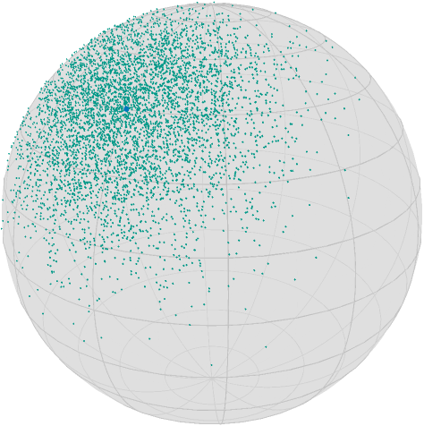

```julia
PlutoUI.LocalResource(image_prefix * "/center_and_large_data.png")
```

Note that due to the construction of the points as zero mean tangent vectors, the mean should be very close to our initial point `x`.

In order to use the stochastic gradient, we now need a function that returns the vector of gradients. There are two ways to define it in `Manopt.jl`: either as a single function that returns a vector, or as a vector of functions.

The first variant is of course easier to define, but the second is more efficient when only evaluating one of the gradients.

For the mean, the gradient is

$$ gradF(x) = \sum_{i=1}^N \operatorname{grad}f_i(x) \quad \text{where} \operatorname{grad}f_i(x) = -\log_x p_i$$

which we define in `Manopt.jl` in two different ways: either as one function returning all gradients as a vector (see `gradF`), or – maybe more fitting for a large scale problem, as a vector of small gradient functions (see `gradf`)

```julia
F(M, x) = 1 / (2 * n) * sum(map(p -> distance(M, x, p)^2, data))
```

```
F (generic function with 1 method)
```

```julia
gradF(M, x) = [grad_distance(M, p, x) for p in data]
```

```
gradF (generic function with 1 method)
```

```julia
gradf = [(M, x) -> grad_distance(M, p, x) for p in data];
```

The calls are only slightly different, but notice that accessing the 2nd gradient element requires evaluating all logs in the first function. So while you can use both `gradF` and `gradf` in the following call, the second one is (much) faster:

```julia
x_opt1 = stochastic_gradient_descent(M, gradF, x)
```

```
3-element Vector{Float64}:
 0.7071067811865475
 0.0
 0.7071067811865475
```

```julia
@benchmark stochastic_gradient_descent($M, $gradF, $x)
```

```
BenchmarkTools.Trial: 3566 samples with 1 evaluation.
 Range (min … max):  971.904 μs …   8.682 ms  ┊ GC (min … max): 0.00% … 82.44%
 Time  (median):       1.254 ms               ┊ GC (median):    0.00%
 Time  (mean ± σ):     1.396 ms ± 834.419 μs  ┊ GC (mean ± σ):  6.96% ± 10.29%

   ▃█▅
  ▆███▆▃▃▃▃▂▂▂▂▂▂▂▂▂▂▂▂▂▂▂▂▂▁▂▁▁▁▁▂▁▁▁▁▁▁▁▁▂▁▁▁▁▁▁▁▁▁▁▂▂▁▂▂▂▂▂▂ ▂
  972 μs           Histogram: frequency by time         7.24 ms <

 Memory estimate: 861.45 KiB, allocs estimate: 10030.
```

```julia
x_opt2 = stochastic_gradient_descent(M, gradf, x)
```

```
3-element Vector{Float64}:
 0.7071067811865475
 0.0
 0.7071067811865475
```

```julia
@benchmark stochastic_gradient_descent($M, $gradf, $x)
```

```
BenchmarkTools.Trial: 10000 samples with 5 evaluations.
 Range (min … max):   6.240 μs … 739.103 μs  ┊ GC (min … max):  0.00% … 94.61%
 Time  (median):      7.680 μs               ┊ GC (median):     0.00%
 Time  (mean ± σ):   11.496 μs ±  36.791 μs  ┊ GC (mean ± σ):  18.39% ±  5.79%

  ▂▆█▇▆▄▂▁▁▃▄▄▃▁    ▁▂                                         ▂
  ███████████████▇▇████▇▆▅▆▆▇▇▇▆▅▅▆▄▄▅▅▅▅▄▄▃▅▄▅▆▆▆▇▇▇▇▆▆▆▄▆▅▆▆ █
  6.24 μs       Histogram: log(frequency) by time      31.8 μs <

 Memory estimate: 40.98 KiB, allocs estimate: 23.
```

```julia
x_opt2
```

```
3-element Vector{Float64}:
 0.7071067811865475
 0.0
 0.7071067811865475
```

This result is reasonably close. But we can improve it by using a `DirectionUpdateRule`, namely:

On the one hand [`MomentumGradient`](https://manoptjl.org/stable/solvers/gradient_descent.html#Manopt.MomentumGradient), which requires both the manifold and the initial value, in order to keep track of the iterate and parallel transport the last direction to the current iterate. You can also set a `vector_transport_method`, if `ParallelTransport()` is not available on your manifold. Here, we simply do

```julia
x_opt3 = stochastic_gradient_descent(
    M, gradf, x; direction=MomentumGradient(M, x, StochasticGradient(zero_vector(M, x)))
)
```

```
3-element Vector{Float64}:
 0.7071067811865475
 0.0
 0.7071067811865475
```

```julia
MG = MomentumGradient(M, x, StochasticGradient(zero_vector(M, x)));
```

```julia
@benchmark stochastic_gradient_descent($M, $gradf, $x; direction=$MG)
```

```
BenchmarkTools.Trial: 10000 samples with 6 evaluations.
 Range (min … max):   5.467 μs …  1.143 ms  ┊ GC (min … max):  0.00% … 0.00%
 Time  (median):      7.600 μs              ┊ GC (median):     0.00%
 Time  (mean ± σ):   12.012 μs ± 37.799 μs  ┊ GC (mean ± σ):  18.83% ± 6.28%

   ▂▆█▇▅▃▂▄▅▄▂▁▁▂▃▁                ▁▁                         ▂
  ▇█████████████████████▇▇▆▅▅▅▅▅▄▅▇████▇▇▆▇▇▆▇▇▆▆▆▆▇▅▅▅▅▅▄▄▅▅ █
  5.47 μs      Histogram: log(frequency) by time      34.9 μs <

 Memory estimate: 40.91 KiB, allocs estimate: 22.
```

And on the other hand the [`AverageGradient`](https://manoptjl.org/stable/solvers/gradient_descent.html#Manopt.AverageGradient) computes an average of the last `n` gradients, i.e.

```julia
x_opt4 = stochastic_gradient_descent(
    M, gradf, x; direction=AverageGradient(M, x, 10, StochasticGradient(zero_vector(M, x)))
);
```

```julia
AG = AverageGradient(M, x, 10, StochasticGradient(zero_vector(M, x)));
```

```julia
@benchmark stochastic_gradient_descent($M, $gradf, $x; direction=$AG)
```

```
BenchmarkTools.Trial: 10000 samples with 5 evaluations.
 Range (min … max):   3.860 μs … 841.644 μs  ┊ GC (min … max):  0.00% … 96.73%
 Time  (median):      7.580 μs               ┊ GC (median):     0.00%
 Time  (mean ± σ):   11.719 μs ±  41.249 μs  ┊ GC (mean ± σ):  20.00% ±  5.78%

       ▄██▆▄▂▁▂▄▅▄▂▁ ▁▂▂▁                                      ▂
  ███▇██████████████▇█████▇▇▇▇▇▇▆▄▅▂▄▅▄▅▆██▇▆▆▅▅▇▆▇▆▆▄▄▅▄▅▄▄▄▅ █
  3.86 μs       Histogram: log(frequency) by time      33.1 μs <

 Memory estimate: 40.91 KiB, allocs estimate: 22.
```

Note that the default `StoppingCriterion` is a fixed number of iterations which helps the comparison here.

For both update rules we have to internally specify that we are still in the stochastic setting (since both rules can also be used with the `IdentityUpdateRule` within `gradient_descent`.

```julia
fullGradF(M, x) = sum(grad_distance(M, p, x) for p in data)
```

```
fullGradF (generic function with 1 method)
```

```julia
x_opt5 = gradient_descent(M, F, fullGradF, x; stepsize=ArmijoLinesearch())
```

```
3-element Vector{Float64}:
  0.7071067811865475
 -2.6313508459800503e-16
  0.7071067811865475
```

```julia
AL = ArmijoLinesearch();
```

```julia
@benchmark gradient_descent($M, $F, $fullGradF, $x; stepsize=$AL)
```

```
BenchmarkTools.Trial: 5 samples with 1 evaluation.
 Range (min … max):  1.150 s …   1.210 s  ┊ GC (min … max): 8.25% … 7.40%
 Time  (median):     1.173 s              ┊ GC (median):    8.09%
 Time  (mean ± σ):   1.178 s ± 22.620 ms  ┊ GC (mean ± σ):  8.03% ± 0.39%

  █                 █  █             █                    █
  █▁▁▁▁▁▁▁▁▁▁▁▁▁▁▁▁▁█▁▁█▁▁▁▁▁▁▁▁▁▁▁▁▁█▁▁▁▁▁▁▁▁▁▁▁▁▁▁▁▁▁▁▁▁█ ▁
  1.15 s         Histogram: frequency by time        1.21 s <

 Memory estimate: 711.73 MiB, allocs estimate: 9038266.
```